# Heatmaps in R

sahir

June 10, 2015

In every statistical analysis, the first thing one should do is try and visualise the data before any modeling. In microarray studies, a common visualisation is a heatmap of gene expression data. In this post I simulate some gene expression data and visualise it using the `pheatmap` function from the [pheatmap](http://cran.r-project.org/web/packages/pheatmap/) package in `R`. You will also need the `mvrnorm` function from the [MASS](http://cran.r-project.org/web/packages/MASS/index.html) library to simulate from a multivariate normal distribution, and the `brewer.pal` function from the [RColorBrewer](http://cran.r-project.org/web/packages/RColorBrewer/index.html) library for easier customization of colors.

## Components of a Heatmap

There are three main components that should be considered when drawing a heatmap:

1. Choosing the color scheme
2. Annotating the rows and/or columns
3. Clustering

### Choosing the color scheme

To avoid wasting time choosing colors, I recommend using the [RColorBrewer](http://cran.r-project.org/web/packages/RColorBrewer/index.html) package based on the design of geographer [Cynthia Brewer](http://colorbrewer2.org/). From the [RColorBrewer](http://cran.r-project.org/web/packages/RColorBrewer/index.html) help page:

> There are 3 types of palettes, sequential, diverging, and qualitative.
> 1. Sequential palettes are suited to ordered data that progress from low to high. Lightness steps dominate the look of these schemes, with light colors for low data values to dark colors for high data values.
> 2. Diverging palettes put equal emphasis on mid-range critical values and extremes at both ends of the data range. The critical class or break in the middle of the legend is emphasized with light colors and low and high extremes are emphasized with dark colors that have contrasting hues.
> 3. Qualitative palettes do not imply magnitude differences between legend classes, and hues are used to create the primary visual differences between classes. Qualitative schemes are best suited to representing nominal or categorical data

### Clustering

First I simulate some gene expression data for genes which are correlated conditional on an exposure status:

```r
# Initiate Simulation parameters
  n = 100       # total number of subjects
  n0 = 50       # number of subjects with X=0
  n1 = n - n0   # number of subjects with X=1
  p = 100       # number of genes
  times = 1:p   # used for creating covariance matrix
  rho.0 = 0.01  # rho between Z_i and Z_j when X=0
  rho.1 = 0.95  # rho between Z_i and Z_j when X=1
  sigma = 1

# Simulate gene expression values according to exposure X=0, X=1, according to a centered multivariate normal distribution with covariance between Z_i and Z_j being rho^|i-j|
  H <- abs(outer(times, times, "-"))
  V0 <- sigma * rho.0^H
  V1 <- sigma * rho.1^H

  # rows are people, columns are genes
  genes0 <- MASS::mvrnorm(n = n0, mu = rep(0,p), Sigma = V0)
  genes1 <- MASS::mvrnorm(n = n1, mu = rep(0,p), Sigma = V1)
  genes <- rbind(genes0,genes1)
  dim(genes)
```

```
## [1] 100 100
```

In order to properly label the heatmap, we must label the matrix of gene expressions:

```r
colnames(genes) <- paste0("Gene", 1:p)
rownames(genes) <- paste0("Subject", 1:n)
genes[1:5, 1:5]
```

```
##               Gene1       Gene2      Gene3      Gene4       Gene5
## Subject1 -1.2933689 -0.51315954  1.0285488 -0.4180129  0.08543911
## Subject2  0.5274182  2.06633679  1.0818713 -0.4031005  1.60846492
## Subject3 -0.1629581 -2.31147887  0.4431405 -1.0518179  0.81174308
## Subject4 -1.8151982  0.69702732 -2.1844601 -0.5620614 -0.01165123
## Subject5  0.8011596 -0.07741283  0.3446539 -0.8195232  0.23083948
```

Because we want to clearly identify the subjects who were exposed and not exposed on the heatmap, we first need to create a separate data frame which contains that information. This data frame can contain many columns, but in this example we only want to annotate the exposure status. Note that the rownames of this data frame need to correspond to the rownames in the gene expression data created above:

```r
library(magrittr) # for piping operator

annotation_col <- rep("X=0",n0) %>%
                  c(rep("X=1", n1)) %>%
                  factor %>%
                  data.frame

colnames(annotation_col) <- "Exposure"

rownames(annotation_col) = paste0("Subject", 1:n)
annotation_col %>% head
```

```
##          Exposure
## Subject1      X=0
## Subject2      X=0
## Subject3      X=0
## Subject4      X=0
## Subject5      X=0
## Subject6      X=0
```

To see the palettes available for coloring the heatmap:

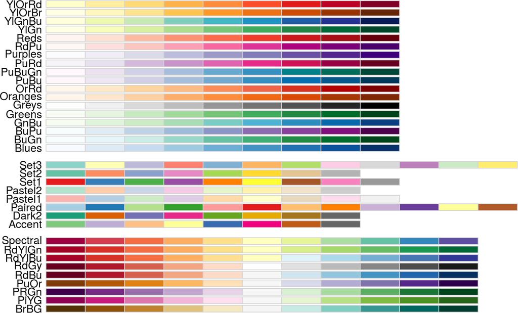

```r
RColorBrewer::display.brewer.all()
```

The pheatmap comes with lots of customizations (see the [help page](http://cran.r-project.org/web/packages/pheatmap/pheatmap.pdf) for a complete list of options). In this example I don’t want to perform any clustering and I want a gap between the exposed and unexposed. Note that we must pass the transpose of the matrix for the `pheatmap` function, which is not the case for other functions such as `gplots::heatmap.2`.

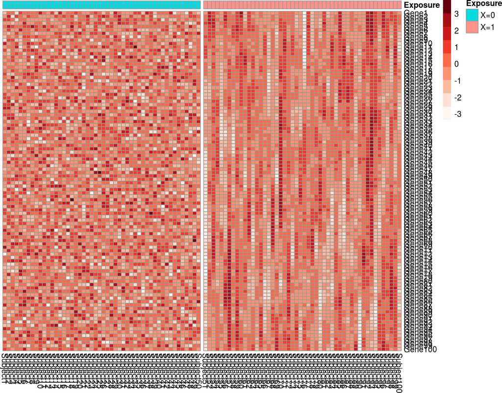

```r
col.pal <- RColorBrewer::brewer.pal(9,"Reds")

pheatmap::pheatmap(t(genes),
                   cluster_row=F,
                   annotation_col = annotation_col,
                   color = col.pal,
                   cluster_cols = F,
                   gaps_col=50)
```